# EDA-challenge, exercise 3

Riley N Derby

2024-02-05

time to do exercise 3

first we need to get csv off a url

```r
library(tidyverse)
library(dplyr)

f <- "https://raw.githubusercontent.com/difiore/ada-2024-datasets/main/data-wrangling.csv"
d <- read_csv(f, col_names = TRUE)  # creates a 'tibble'
head(d)
```

```
## # A tibble: 6 × 23
##   Scientific_Name             Family        Genus Species Brain_Size_Species_M…¹
##   <chr>                       <chr>         <chr> <chr>                    <dbl>
## 1 Allenopithecus_nigroviridis Cercopitheci… Alle… nigrov…                   58.0
## 2 Allocebus_trichotis         Cercopitheci… Allo… tricho…                   NA
## 3 Alouatta_belzebul           Atelidae      Alou… belzeb…                   52.8
## 4 Alouatta_caraya             Atelidae      Alou… caraya                    52.6
## 5 Alouatta_guariba            Atelidae      Alou… guariba                   51.7
## 6 Alouatta_palliata           Atelidae      Alou… pallia…                   49.9
## # ℹ abbreviated name: ¹Brain_Size_Species_Mean
## # ℹ 18 more variables: Body_mass_male_mean <dbl>, Body_mass_female_mean <dbl>,
## #   MeanGroupSize <dbl>, AdultMales <dbl>, AdultFemale <dbl>,
## #   GR_MidRangeLat_dd <dbl>, Precip_Mean_mm <dbl>, Temp_Mean_degC <dbl>,
## #   HomeRange_km2 <dbl>, DayLength_km <dbl>, Fruit <dbl>, Leaves <chr>,
## #   Fauna <chr>, Canine_Dimorphism <dbl>, Feed <dbl>, Move <dbl>, Rest <dbl>,
## #   Social <dbl>
```

now lets get the structure

```r
str(d)
```

```
## spc_tbl_ [213 × 23] (S3: spec_tbl_df/tbl_df/tbl/data.frame)
##  $ Scientific_Name        : chr [1:213] "Allenopithecus_nigroviridis" "Allocebus_trichotis" "Alouatta_belzebul" "Alouatta_caraya" ...
##  $ Family                 : chr [1:213] "Cercopithecidae" "Cercopithecidae" "Atelidae" "Atelidae" ...
##  $ Genus                  : chr [1:213] "Allenopithecus" "Allocebus" "Alouatta" "Alouatta" ...
##  $ Species                : chr [1:213] "nigroviridis" "trichotis" "belzebul" "caraya" ...
##  $ Brain_Size_Species_Mean: num [1:213] 58 NA 52.8 52.6 51.7 ...
##  $ Body_mass_male_mean    : num [1:213] 6130 92 7270 6525 5800 ...
##  $ Body_mass_female_mean  : num [1:213] 3180 84 5520 4240 4550 5350 6430 5210 1230 NA ...
##  $ MeanGroupSize          : num [1:213] NA 1 7 8 6.53 12 6.6 7.1 3.1 3 ...
##  $ AdultMales             : num [1:213] NA 1 1 2.3 1.37 ...
##  $ AdultFemale            : num [1:213] NA 1 1 3.3 2.2 ...
##  $ GR_MidRangeLat_dd      : num [1:213] -0.17 -16.59 -6.8 -20.34 -21.13 ...
##  $ Precip_Mean_mm         : num [1:213] 1574 1902 1644 1166 1332 ...
##  $ Temp_Mean_degC         : num [1:213] 25.2 20.3 24.9 22.9 19.6 23.7 25.1 25.1 24.6 NA ...
##  $ HomeRange_km2          : num [1:213] NA NA NA NA 0.03 0.19 0.3 0.1 0.095 NA ...
##  $ DayLength_km           : num [1:213] NA NA NA 0.4 NA 0.32 NA 0.55 NA NA ...
##  $ Fruit                  : num [1:213] NA NA 57.3 23.8 5.2 33.1 40.8 40 45 NA ...
##  $ Leaves                 : chr [1:213] NA NA "19.1" "67.7" ...
##  $ Fauna                  : chr [1:213] NA NA "0" "0" ...
##  $ Canine_Dimorphism      : num [1:213] 2.21 NA 1.81 1.54 1.78 ...
##  $ Feed                   : num [1:213] NA NA 13.8 15.9 18.3 ...
##  $ Move                   : num [1:213] NA NA 18.8 17.6 14.3 ...
##  $ Rest                   : num [1:213] NA NA 57.3 61.6 64.4 ...
##  $ Social                 : num [1:213] NA NA 10 4.9 3 3.64 3.8 2.5 NA NA ...
##  - attr(*, "spec")=
##   .. cols(
##   ..   Scientific_Name = col_character(),
##   ..   Family = col_character(),
##   ..   Genus = col_character(),
##   ..   Species = col_character(),
##   ..   Brain_Size_Species_Mean = col_double(),
##   ..   Body_mass_male_mean = col_double(),
##   ..   Body_mass_female_mean = col_double(),
##   ..   MeanGroupSize = col_double(),
##   ..   AdultMales = col_double(),
##   ..   AdultFemale = col_double(),
##   ..   GR_MidRangeLat_dd = col_double(),
##   ..   Precip_Mean_mm = col_double(),
##   ..   Temp_Mean_degC = col_double(),
##   ..   HomeRange_km2 = col_double(),
##   ..   DayLength_km = col_double(),
##   ..   Fruit = col_double(),
##   ..   Leaves = col_character(),
##   ..   Fauna = col_character(),
##   ..   Canine_Dimorphism = col_double(),
##   ..   Feed = col_double(),
##   ..   Move = col_double(),
##   ..   Rest = col_double(),
##   ..   Social = col_double()
##   .. )
##  - attr(*, "problems")=<externalptr>
```

```r
glimpse(d)
```

```
## Rows: 213
## Columns: 23
## $ Scientific_Name         <chr> "Allenopithecus_nigroviridis", "Allocebus_tric…
## $ Family                  <chr> "Cercopithecidae", "Cercopithecidae", "Atelida…
## $ Genus                   <chr> "Allenopithecus", "Allocebus", "Alouatta", "Al…
## $ Species                 <chr> "nigroviridis", "trichotis", "belzebul", "cara…
## $ Brain_Size_Species_Mean <dbl> 58.02, NA, 52.84, 52.63, 51.70, 49.88, 51.13, …
## $ Body_mass_male_mean     <dbl> 6130.0, 92.0, 7270.0, 6525.0, 5800.0, 7150.0, …
## $ Body_mass_female_mean   <dbl> 3180.0, 84.0, 5520.0, 4240.0, 4550.0, 5350.0, …
## $ MeanGroupSize           <dbl> NA, 1.000, 7.000, 8.000, 6.530, 12.000, 6.600,…
## $ AdultMales              <dbl> NA, 1.000, 1.000, 2.300, 1.370, 2.900, 1.925, …
## $ AdultFemale             <dbl> NA, 1.000, 1.000, 3.300, 2.200, 6.300, 2.175, …
## $ GR_MidRangeLat_dd       <dbl> -0.17, -16.59, -6.80, -20.34, -21.13, 6.95, 18…
## $ Precip_Mean_mm          <dbl> 1574.0, 1902.3, 1643.5, 1166.4, 1332.3, 1852.6…
## $ Temp_Mean_degC          <dbl> 25.2, 20.3, 24.9, 22.9, 19.6, 23.7, 25.1, 25.1…
## $ HomeRange_km2           <dbl> NA, NA, NA, NA, 0.030, 0.190, 0.300, 0.100, 0.…
## $ DayLength_km            <dbl> NA, NA, NA, 0.400, NA, 0.320, NA, 0.550, NA, N…
## $ Fruit                   <dbl> NA, NA, 57.3, 23.8, 5.2, 33.1, 40.8, 40.0, 45.…
## $ Leaves                  <chr> NA, NA, "19.1", "67.7", "73", "56.4", "45.1", …
## $ Fauna                   <chr> NA, NA, "0", "0", "0", "0", "0", "0", NA, NA, …
## $ Canine_Dimorphism       <dbl> 2.210, NA, 1.811, 1.542, 1.783, 1.703, 1.109, …
## $ Feed                    <dbl> NA, NA, 13.75, 15.90, 18.33, 17.94, 24.40, 12.…
## $ Move                    <dbl> NA, NA, 18.75, 17.60, 14.33, 12.32, 9.80, 6.20…
## $ Rest                    <dbl> NA, NA, 57.30, 61.60, 64.37, 66.14, 61.90, 78.…
## $ Social                  <dbl> NA, NA, 10.00, 4.90, 3.00, 3.64, 3.80, 2.50, N…
```

Create a new variable named BSD (body size dimorphism) which is the ratio of average male to female body mass.

```r
d$BSD <- d$Body_mass_male_mean/d$Body_mass_female_mean
```

Create a new variable named sex_ratio, which is the ratio of the number of adult females to adult males in a typical group.

```r
d$sex_ratio <- d$AdultFemale/d$AdultMales
```

lets calculate diameter so d = 2(sqrt(hr/pi))

```r
diameter <- (2*sqrt((d$HomeRange_km2)/(pi)))

diameter
```

```
##   [1]         NA         NA         NA         NA 0.19544100 0.49184908
##   [7] 0.61803872 0.35682482 0.34778982         NA         NA         NA
##  [13] 0.36563664 0.15957691         NA         NA 1.70381518         NA
##  [19] 0.96408758 1.31590493 0.11283792 0.11283792 1.15072548 0.72515373
##  [25] 2.58544147         NA         NA         NA 0.29854107 0.24462677
##  [31] 0.60765078 0.63830765         NA 0.31915382         NA 0.35682482
##  [37] 0.15957691         NA 0.11283792 0.05046265 0.82147243 1.05851349
##  [43] 0.66755812 1.47122644         NA         NA 0.80582391         NA
##  [49]         NA         NA 0.45135167 0.11283792 0.55279064 1.26156626
##  [55]         NA         NA         NA 0.35682482         NA 0.27639532
##  [61] 1.21005185         NA 1.21005185         NA         NA         NA
##  [67] 0.15957691 0.15957691 1.69256875         NA         NA         NA
##  [73] 2.17341177 0.61803872 0.79788456 1.86097060 0.60765078 0.67325573
##  [79] 5.99635596 0.40684289         NA 0.94406974 0.39573787 0.45416385
##  [85] 0.25977239 0.23124892 0.50462650 0.86230615 0.29854107         NA
```

[output cut: 21 more lines]

```r
d$diameter <- diameter
```

Create a new variable named DI (for “defensibility index”), which is the ratio of day range length to the diameter of the home range

```r
d$DI <- d$DayLength_km/d$diameter
```

plot the relationship between day range length and time moving for overall

```r
library(ggplot2)
names(d)
```

```
##  [1] "Scientific_Name"         "Family"
##  [3] "Genus"                   "Species"
##  [5] "Brain_Size_Species_Mean" "Body_mass_male_mean"
##  [7] "Body_mass_female_mean"   "MeanGroupSize"
##  [9] "AdultMales"              "AdultFemale"
## [11] "GR_MidRangeLat_dd"       "Precip_Mean_mm"
## [13] "Temp_Mean_degC"          "HomeRange_km2"
## [15] "DayLength_km"            "Fruit"
## [17] "Leaves"                  "Fauna"
## [19] "Canine_Dimorphism"       "Feed"
## [21] "Move"                    "Rest"
## [23] "Social"                  "BSD"
## [25] "sex_ratio"               "diameter"
## [27] "DI"
```

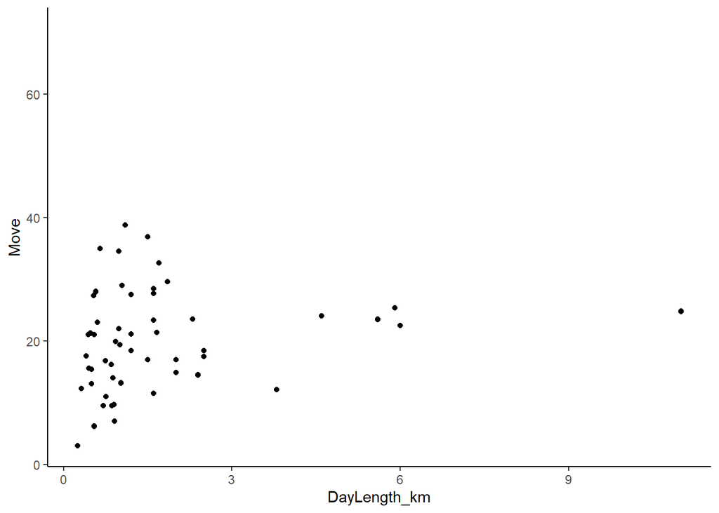

```r
fig1 <-ggplot(d, aes(x = DayLength_km , y = Move))+
  geom_point()+
  geom_point(position = "jitter")+
  theme_classic()

fig1
```

now log it

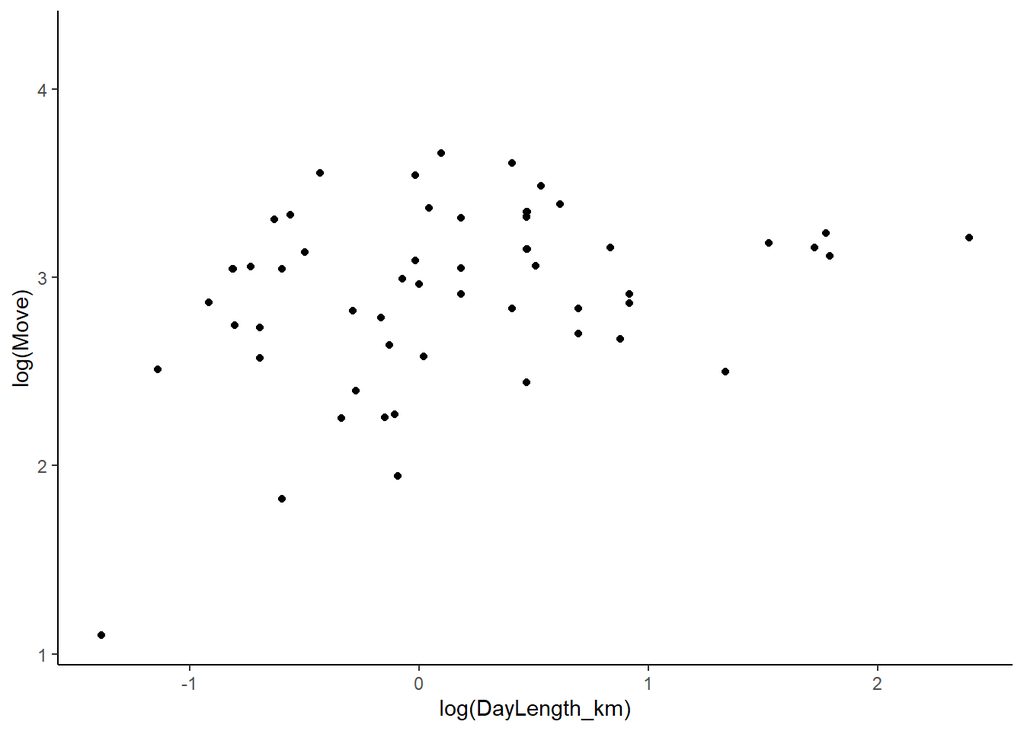

```r
fig1 <-ggplot(d, aes(x = log(DayLength_km) , y = log(Move)))+
  geom_point()+
  geom_point(position = "jitter")+
  theme_classic()

fig1
```

now plot it by families rather than just overall

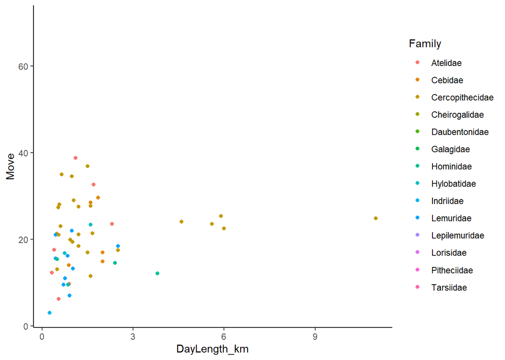

```r
fig2 <-ggplot(d, aes(x = DayLength_km , y = Move, color = Family))+
  geom_point(na.rm = T)+
  theme_classic()

fig2
```

log family one too

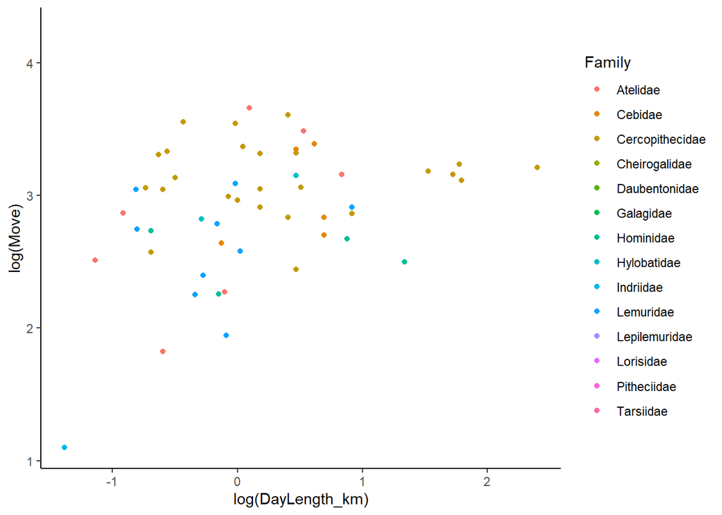

```r
fig2 <-ggplot(d, aes(x = log(DayLength_km) , y = log(Move), color = Family))+
  geom_point()+
  theme_classic()

fig2
```

add regression lines for families

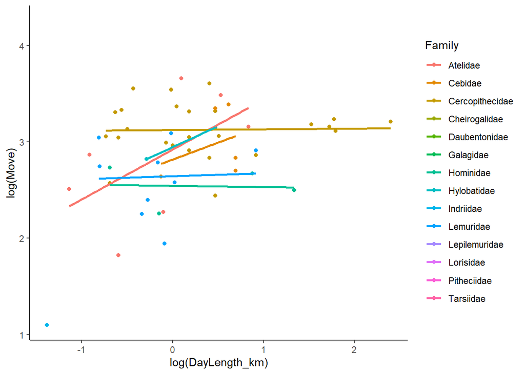

```r
ggplot(data = d, aes(x = log(DayLength_km), y = log(Move), color = Family)) +
  geom_point(na.rm = TRUE) +
  theme_classic() +
  geom_smooth(method = "lm", se = FALSE)
```

Plot the relationship between day range length and time group size, overall and by family. Do species that live in larger groups travel farther overall? How about within any particular primate family? Should you transform either of these variables?

plot day range and group size

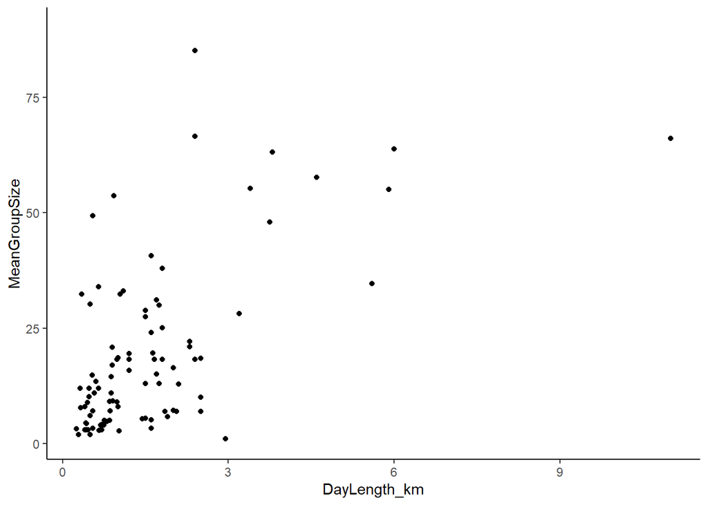

```r
ggplot(data = d, aes(x = DayLength_km, y = MeanGroupSize)) +
  geom_point()+
  theme_classic()
```

log it

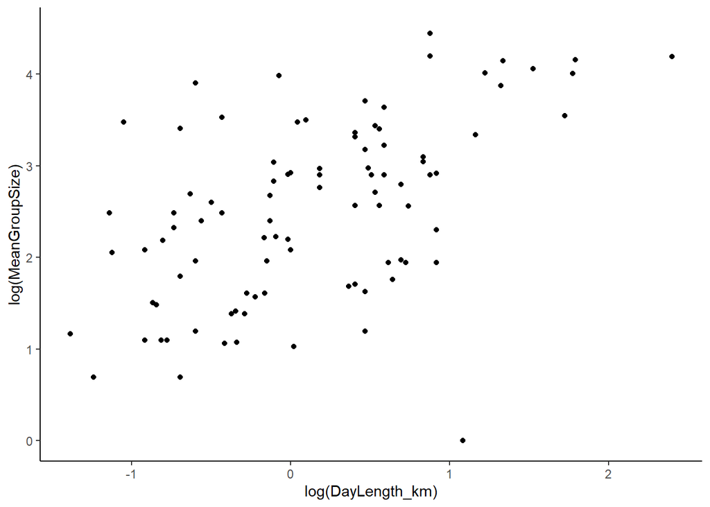

```r
ggplot(data = d, aes(x = log(DayLength_km), y = log(MeanGroupSize))) +
  geom_point()+
  theme_classic()
```

color by family

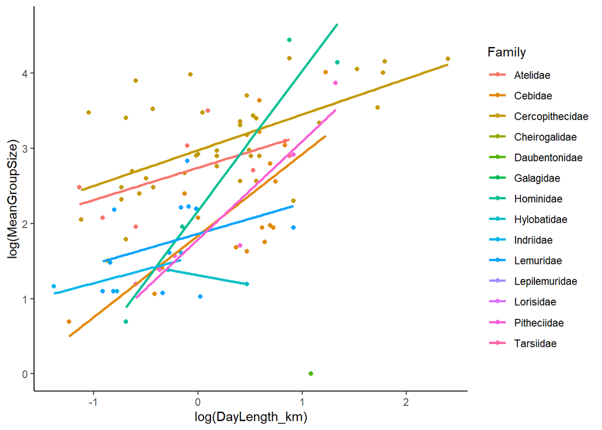

```r
ggplot(data = d, aes(x = log(DayLength_km), y = log(MeanGroupSize), color = Family)) +
  geom_point()+
  theme_classic()+
  geom_smooth(method = 'lm', se = F)
```

Plot the relationship between body size dimorphism and canine size dimorphism overall and by family. Do taxa with greater size dimorphism also show greater canine dimorphism?

BSD VS Canine

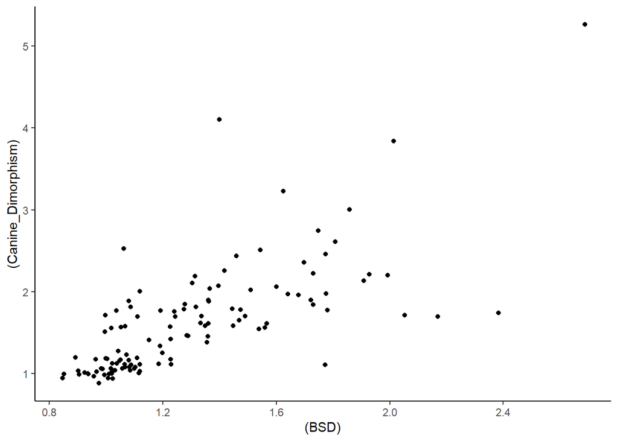

```r
ggplot(data = d, aes(x = (BSD), y = (Canine_Dimorphism))) +
  geom_point()+
  theme_classic()
```

log it

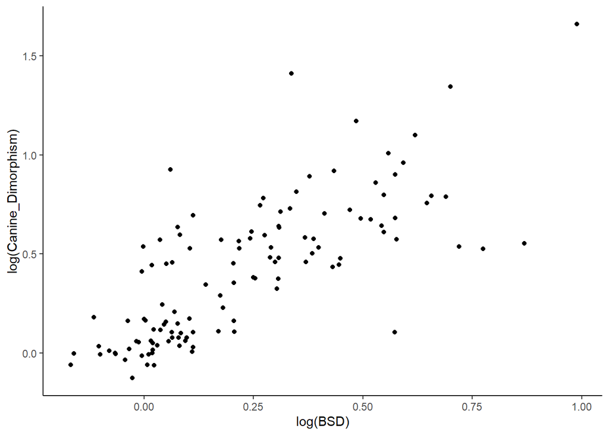

```r
ggplot(data = d, aes(x = log(BSD), y = log(Canine_Dimorphism))) +
  geom_point()+
  theme_classic()
```

color by family

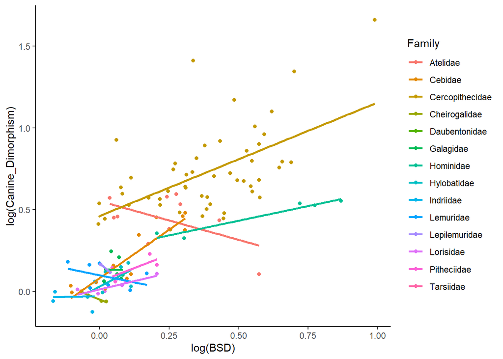

```r
ggplot(data = d, aes(x = log(BSD), y = log(Canine_Dimorphism), color = Family)) +
  geom_point()+
  theme_classic()+
  geom_smooth(method = 'lm', se = F)
```

Create a new variable named diet_strategy that is “frugivore” if fruits make up >50% of the diet, “folivore” if leaves make up >50% of the diet, and “omnnivore” if neither of these is true. Then, do boxplots of group size for species with different dietary strategies. Do frugivores live in larger groups than folivores?

create new variable

```r
library(dplyr)


diet_strategy <- d %>%
  select(Fruit, Leaves) %>%
  mutate(diet_strategy = case_when(
    Fruit >= 50 ~ "Frugivore",
    Leaves >= 50 ~ "Folivore",
    .default = "Omnivore"
  ))
diet_strategy
```

```
## # A tibble: 213 × 3
##    Fruit Leaves diet_strategy
##    <dbl> <chr>  <chr>
##  1  NA   <NA>   Omnivore
##  2  NA   <NA>   Omnivore
##  3  57.3 19.1   Frugivore
##  4  23.8 67.7   Folivore
##  5   5.2 73     Folivore
##  6  33.1 56.4   Folivore
##  7  40.8 45.1   Omnivore
##  8  40   48.1   Omnivore
##  9  45   41     Omnivore
## 10  NA   <NA>   Omnivore
## # ℹ 203 more rows
```

boxplot diet strat vs group size

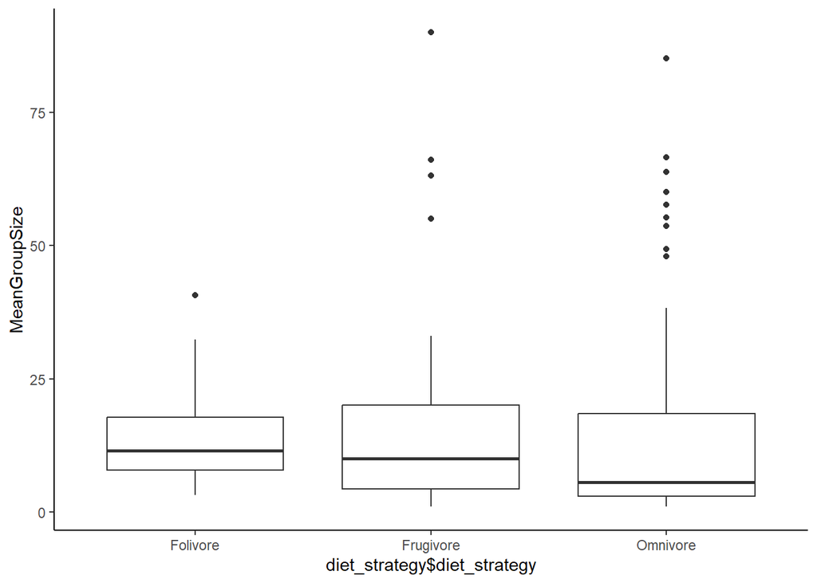

```r
ggplot(data = d, aes(x = diet_strategy$diet_strategy, y = MeanGroupSize)) +
  geom_boxplot() +
  theme_classic()
```

In one line of code, using {dplyr} verbs and the forward pipe (%>% or |>) operator, do the following: Add a variable, Binomial to the data frame d, which is a concatenation of the Genus and Species… Trim the data frame to only include the variables Binomial, Family, Brain_size_species_mean, and Body_mass_male_mean… Group these variables by Family… Calculate the average value for Brain_size_species_mean and Body_mass_male_mean per Family (remember, you may need to specify na.rm = TRUE)… And arrange by increasing average brain size

```r
s <- d %>% mutate(Binomial = paste0(Genus, "_", Species)) %>%
  select(Binomial, Family, Brain_Size_Species_Mean, Body_mass_male_mean) %>%
  group_by(Family)%>%
  summarise(avg_brain_size = mean(Brain_Size_Species_Mean, na.rm = T), avgM_body_size = mean(Body_mass_male_mean, na.rm = T))%>%
  arrange(avg_brain_size)
```